# Pricing an option on many cores

## Pricing an option on many cores

SIMD, OpenMP and hybrid MPI for a Heston PDE solver

Zain Al-Saffi, 48008361

COSC3500 Milestone 2, October 2026

## What an option is

A call option is the right to buy one share at a fixed price, the strike $K = 5250$, in 3 months

[figure not shown]

## From the model to the PDE

In the Heston model the share price and its volatility both move randomly, and the value $V(S, v, t)$ follows one PDE

\(V_t\)

+

\(\tfrac{1}{2} v S^2 V_{SS}\)the share price moves randomly

+

\(\rho \xi v S\, V_{Sv}\)the two move together, ρ = −0.7

+

\(\tfrac{1}{2} \xi^2 v\, V_{vv}\)the volatility moves randomly

+

\((r - q) S\, V_S\)the share grows at the interest rate

+

\(\kappa(\theta - v)\, V_v\)the volatility returns towards 0.04

−

\(r V\)money later is worth less today

= 0

$v$ is the variance, the square of the volatility. Each coloured term comes from one part of the model.

[figure not shown]

S. L. Heston, A closed-form solution for options with stochastic volatility with applications to bond and currency options, *Review of Financial Studies* 6(2), 327 to 343, 1993.

## Finite differences on one cell

Each derivative from the cells next to it, worked out at $S = 5250$, $v = 0.04$ on the first step back

\(V_t\)

+

\(\tfrac{1}{2} v S^2 V_{SS}\)

+

\(\rho \xi v S\, V_{Sv}\)

+

\(\tfrac{1}{2} \xi^2 v\, V_{vv}\)

+

\((r - q) S\, V_S\)

+

\(\kappa(\theta - v)\, V_v\)

−

\(r V\)

= 0

[figure not shown]

## From the PDE to C++

The same cell through the lines of `src/stencil.cpp` that update it

\(V_t\)

+

\(\tfrac{1}{2} v S^2 V_{SS}\)

+

\(\rho \xi v S\, V_{Sv}\)

+

\(\tfrac{1}{2} \xi^2 v\, V_{vv}\)

+

\((r - q) S\, V_S\)

+

\(\kappa(\theta - v)\, V_v\)

−

\(r V\)

= 0

[figure not shown]

## One step over the whole grid

From expiry $T$ to $T - \Delta t$, every new cell from nine old ones

[figure not shown]

A step reads only the old buffer and writes only the new one, so the new cells can be computed in any order.

## The data structure

Two flat arrays of doubles, read one, write the other, then swap

[figure not shown]

```
include/grid.h, line 38
```

```cpp
int index(int stock_i, int var_j) const { return var_j * num_stock_nodes_ + stock_i; }
```

```
include/grid.h, lines 61 to 62
```

```cpp
std::vector<double> current_;
std::vector<double> next_;
```

**16 KiB** one row of 2048 doubles

**8 MiB** one buffer at 2048 x 512

**16 MiB** both buffers

The share price axis is contiguous, so the inner loop reads memory in order, and a step in variance is a stride of one row.

## A full run

56,000 steps on the test grid, from the payoff at expiry back to today

[figure not shown]

The full grid is within a tenth of a cent of the Fourier price, 196.1692. With $\xi = 0$ and $\rho = 0$ Heston becomes Black-Scholes, and the same solver is within 4 cents of the closed form.

## How every number was measured

One exclusive rangpur r730 compute node, through sbatch

[figure not shown]

- Dual Xeon E5-2670 v3, 2 x 12 cores, 30 MiB L3 per socket, g++ 8.5, Open MPI 4.1, with `--exclusive` on a named node so no other job shares it.
- Median of 5 repetitions, with the threads pinned to cores.
- Each job builds from clean and stops unless `make test`, `make test-mpi` and `make avx-check` all pass (`slurm/bench_common.sh` lines 62 to 68).
- The price is printed, so the compiler cannot delete the loop.

A first round was discarded

Short runs leave cells below $2.2 \times 10^{-308}$, and this CPU handles those slowly. How many there were changed with the grid, so the rungs ran in different regimes. Every sweep was rerun with those values flushed to zero, by a library loaded before `main` that sets two bits of the SSE control register.

| Rung | as is | flushed |
| --- | --- | --- |
| baseline | 53 | 57 |
| serial | 124 | 159 |
| simd | 320 | 454 |
| omp 24 | 4865 | 6484 |

Rates are million cell updates per second on the 2048 by 512 grid unless a slide says otherwise.

Denormal numbers, D. Goldberg, What every computer scientist should know about floating-point arithmetic, *ACM Computing Surveys* 23(1), 5 to 48, 1991.

## Where the time goes

gprof on one thread, and the baseline and serial rungs built at -O0 to -O3, 2048 x 512

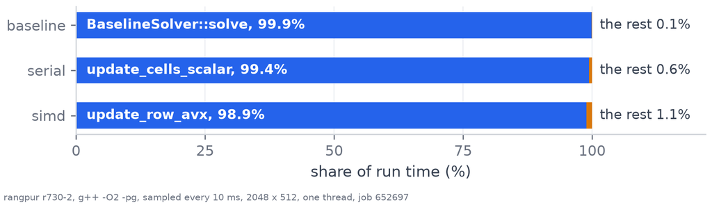

- The baseline goes from 11 at -O0 to 58 at -O2.
- -O3 vectorises with two-lane SSE. That doubles the baseline and gives serial 1.5x.
- Every benchmark builds at -O2, so each rung measures the change written by hand.

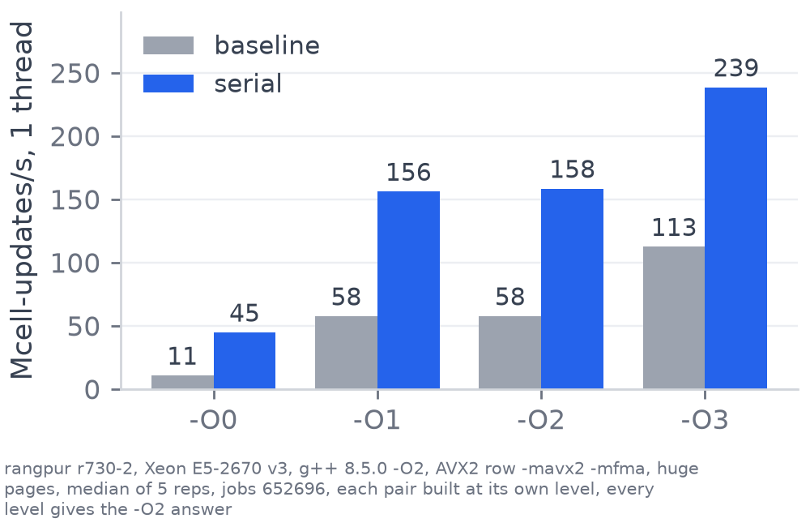

One function takes 99 percent of the time in every single-core rung, so every rung changes that function. At -O3 the compiler takes the baseline to 113, still below the serial rung’s 159 at -O2.

## The serial rung

The baseline divides by the grid spacing in every cell of every step

```
src/solver_baseline.cpp, lines 68 to 72
```

```cpp
double dV_dS = (east - west) / (2.0 * grid.stock_spacing());
double d2V_dS2 = (east - 2.0 * centre + west) / (grid.stock_spacing() * grid.stock_spacing());
double dV_dv = (north - south) / (2.0 * grid.variance_spacing());
double d2V_dv2 = (north - 2.0 * centre + south) / (grid.variance_spacing() * grid.variance_spacing());
double d2V_dS_dv = (north_east - north_west - south_east + south_west) / (4.0 * grid.stock_spacing() * grid.variance_spacing());
```

The compiler may not make this change, since the rounding can differ in the last bit. By hand it gives 159 million updates a second, 2.8x.

## The serial rung

The five divisions done once per solve, then a multiplication in every cell

```
src/stencil.cpp, lines 28 to 32, once per solve
```

```cpp
inv_two_ds = 1.0 / (2.0 * stock_spacing);
inv_ds_sq = 1.0 / (stock_spacing * stock_spacing);
inv_two_dv = 1.0 / (2.0 * variance_spacing);
inv_dv_sq = 1.0 / (variance_spacing * variance_spacing);
inv_four_ds_dv = 1.0 / (4.0 * stock_spacing * variance_spacing);
```

```
src/stencil.cpp, lines 107 to 111, every cell of every step
```

```cpp
double dV_dS = (east - west) * inv_two_ds;
double d2V_dS2 = (east - 2.0 * centre + west) * inv_ds_sq;
double dV_dv = (north - south) * inv_two_dv;
double d2V_dv2 = (north - 2.0 * centre + south) * inv_dv_sq;
double d2V_dS_dv = (north_east - north_west - south_east + south_west) * inv_four_ds_dv;
```

The row also copies every constant into a local variable first (`src/stencil.cpp` lines 66 to 76). It writes through a `double*`, so without the copies the compiler would reload each constant after every store.

The compiler may not make this change, since the rounding can differ in the last bit. By hand it gives 159 million updates a second, 2.8x.

## SIMD, four cells per instruction

Every cell in a row runs the same formula on neighbours that sit next to each other in memory

[figure not shown]

- A 256 bit AVX2 register holds four doubles.
- Four neighbouring cells run the same formula, so one instruction updates all four.
- Each group of four cells needs nine overlapping 256 bit loads.
- The last zero to three cells of a row are computed one at a time.

The serial rung already ran at 96 percent of the scalar peak, so the next gain came from vector instructions.

## SIMD code, before and after

The serial loop, one cell per pass

```
src/stencil.cpp, lines 93 to 123, the serial row, shortened
```

```cpp
for (int stock_i = first_stock; stock_i < end_stock; ++stock_i) {
    double centre = row_centre[stock_i];
    double east = row_centre[stock_i + 1];
    double west = row_centre[stock_i - 1];
    // ...
    out_row[stock_i] = centre + dt * change;
}
```

Each load now reads four doubles and the update is one fused multiply-add, for 456 million updates a second, 2.9x serial.

## SIMD code, before and after

The AVX2 loop, four cells per pass

```
src/stencil_avx.cpp, lines 55 to 112, the AVX2 row, shortened
```

```cpp
while (stock_i + 3 <= last_interior) {
    __m256d centre = _mm256_loadu_pd(row_centre + stock_i);
    __m256d east = _mm256_loadu_pd(row_centre + stock_i + 1);
    __m256d west = _mm256_loadu_pd(row_centre + stock_i - 1);
    // ...
    __m256d new_value = _mm256_fmadd_pd(dt, change, centre);
    _mm256_storeu_pd(out_row + stock_i, new_value);

    stock_i = stock_i + 4;
}
```

Each load now reads four doubles and the update is one fused multiply-add, for 456 million updates a second, 2.9x serial.

## Aligned and unaligned loads

One AVX2 load reads four doubles, 32 bytes, in one instruction

[figure not shown]

Two flags, `-mno-avx256-split-unaligned-load` and `-store` (`Makefile` line 23), keep every load whole, with the same answer and 1.19x the speed on one core. Every number in this video uses them.

## OpenMP, one block of rows per thread

The rows of each step are shared between the cores of one node

[figure not shown]

- The grid has 512 rows, one per variance value. `schedule(static)` gives each of 24 threads one block of 21 or 22 neighbouring rows, the same block every step, so thread 0 updates rows 1 to 22.
- Every thread reads the old buffer and writes only its own rows, so no locks are needed.
- The loop ends with an implicit barrier. Then the main thread updates the boundaries and swaps the buffers.

The code change is one pragma above the row loop.

## OpenMP code

The SIMD rung’s row loop

```
src/solver_simd.cpp, lines 47 to 50
```

```cpp
// Update every interior row, four cells at a time.
for (int var_j = 1; var_j < num_variance_nodes - 1; ++var_j) {
    update_row_avx(constants, current, next, var_j);
}
```

On 24 cores, 6367 million updates a second, 14.0x the SIMD rung. `default(none)` makes a forgotten shared variable a compile error.

## OpenMP code

The same loop with one pragma

```
src/solver_omp.cpp, lines 43 to 48
```

```cpp
// Split the interior rows between the threads, one equal band each.
// Threads only read current and only write their own rows of next, so no locks are needed.
#pragma omp parallel for schedule(static) default(none) shared(constants, current, next, num_variance_nodes)
for (int var_j = 1; var_j < num_variance_nodes - 1; ++var_j) {
    update_row_avx(constants, current, next, var_j);
}
```

On 24 cores, 6367 million updates a second, 14.0x the SIMD rung. `default(none)` makes a forgotten shared variable a compile error.

## Strong scaling

Strong scaling keeps the 2048 x 512 grid fixed and adds threads. How close to 24 times faster does it get?

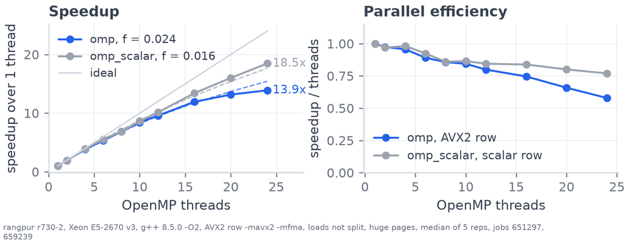

The least squares fit gives f = 2.4 percent for the AVX2 row and 1.6 percent for the scalar row. The boundaries are 0.44 percent of a one-thread step, so most of f is the fork and barrier every step and the shared caches. At 24 threads the AVX2 row moves about 151 GB/s through the caches, 2.2 times the DRAM triad.

13.9x on 24 threads. Amdahl’s law $S = 1 / (f + (1 - f)/p)$ fits a serial fraction $f = 2.4$ percent. The scalar row reaches 18.5x, because each of its threads needs data at a third of the rate.

Amdahl’s law, COSC3500 lecture 3. Fitting $f$ to measured speedups, A. H. Karp and H. P. Flatt, Measuring parallel processor performance, *Communications of the ACM* 33(5), 539 to 543, 1990.

## Weak scaling

Weak scaling gives every thread 21 rows, so the grid grows with the threads. Does the step time stay flat?

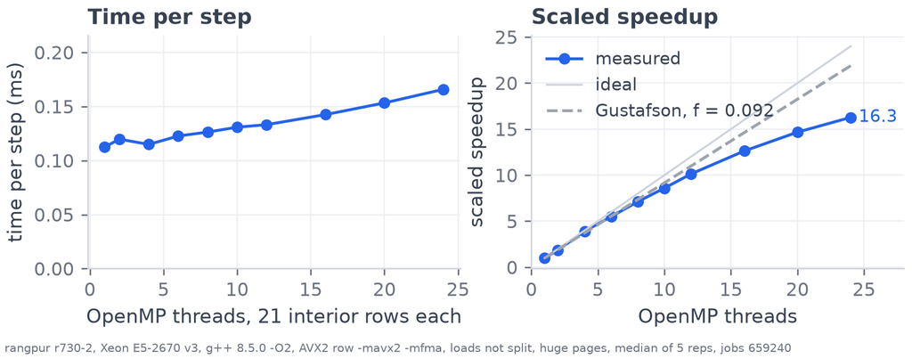

v_max grows with the rows, so the spacing stays the same. At 24 threads the boundaries take 9.2 percent of a step, so Gustafson predicts 24 − 0.092 × 23 = 21.9 against the measured 16.3. The one-thread grid, 370 KiB a buffer, is already larger than a core’s 256 KiB L2.

The step time grows from 0.11 to 0.17 ms, a scaled speedup of 16 on 24 threads. Gustafson’s law $S = f + (1 - f)N$ with $f = 0.09$ predicts 22.

J. L. Gustafson, Reevaluating Amdahl’s law, *Communications of the ACM* 31(5), 532 to 533, 1988.

## Grid size

The same rungs on grids from 1 MiB to 128 MiB of buffers

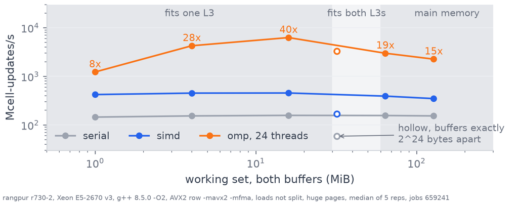

Both buffers fit in the two 30 MiB L3 caches up to 2048 by 512, 16 MiB. The 2896 by 724 points are hollow because that grid puts its two buffers exactly 2<sup>24</sup> bytes apart and every rung is slow there. The grids that trigger it are known, and the hardware cause has not been found.

While both buffers fit in the two L3 caches, 24 threads run 40x serial. At 4096 by 1024 they come from main memory and the rate halves.

## After threads, memory bandwidth

The roofline caps a kernel’s rate by the node’s compute peak or by its memory bandwidth

[figure not shown]

- On 2048 x 512 the grid fits in the L3 caches, so the rung runs above the memory roof.
- On 4096 x 1024 it sits on the memory roof.
- The node’s AVX2 ceiling of 971 GFLOP/s is five times the small grid’s rate.

After threads the limit on the big grid is memory bandwidth, 93 GFLOP/s at a memory roof of about 88.

S. Williams, A. Waterman and D. Patterson, Roofline: an insightful visual performance model for multicore architectures, *Communications of the ACM* 52(4), 65 to 76, 2009.

## MPI, one block of rows per process

Each process updates its own rows and receives one row from each neighbour

[figure not shown]

- Each process owns a block of rows and keeps its own copy of the grid.
- To update its first and last rows it needs one row from each neighbour, held in its copied rows, called ghost rows.
- So every step each process sends its edge rows and receives its neighbours’.
- `rows_for_rank` gives the first processes one extra row when the rows do not divide evenly, and `MPI_Gatherv` collects the blocks once at the end.
- MPI starts with `MPI_THREAD_FUNNELED`, because only the main thread calls it.

On one node, one process of 12 threads per socket fills its own copy of the grid, so its pages are in that socket’s memory.

## MPI code, the edge row exchange

The receive and the send with the neighbour below, then the wait

```
src/solver_mpi.cpp, lines 55 to 65, in post_edge_rows
```

```cpp
// The bottom process has nobody below it.
if (rank > 0) {
    // Post the receive first.
    MPI_Request receive_below;
    MPI_Irecv(row_below, num_stock_nodes, MPI_DOUBLE, rank - 1, message_tag, MPI_COMM_WORLD, &receive_below);
    requests.push_back(receive_below);

    MPI_Request send_below;
    MPI_Isend(first_row, num_stock_nodes, MPI_DOUBLE, rank - 1, message_tag, MPI_COMM_WORLD, &send_below);
    requests.push_back(send_below);
}
```

```
src/solver_mpi.cpp, lines 86 to 87, in exchange_edge_rows
```

```cpp
// Wait for every send and receive to finish.
MPI_Waitall((int)requests.size(), requests.data(), MPI_STATUSES_IGNORE);
```

The receive is posted before the send, and both return immediately. `MPI_Waitall` blocks until every send and receive has completed.

## Placement

Which socket the threads run on, and which socket’s memory holds the pages

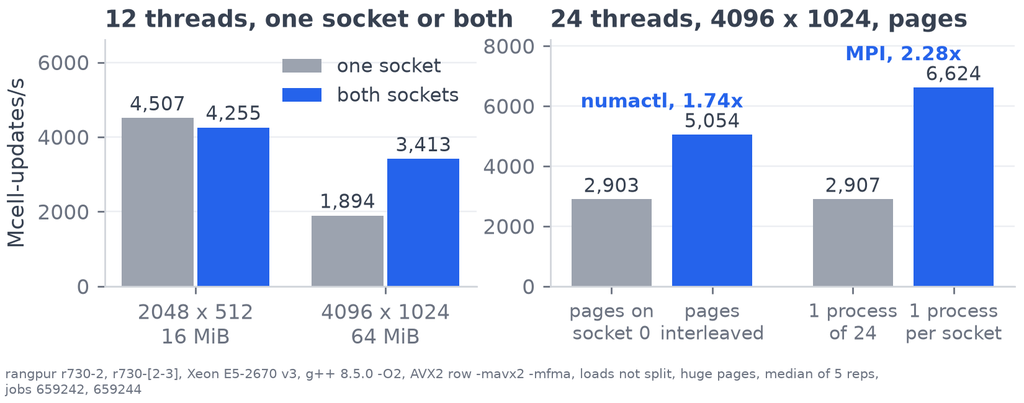

The CPUs are numbered even on socket 0 and odd on socket 1, so `OMP_PROC_BIND=close` splits every even thread count over both sockets. `numactl --interleave=all` made 24 threads 1.74x faster on the big grid (E7), and `MALLOC_MMAP_THRESHOLD_` gives every repetition fresh 2 MiB huge pages.

Two sockets give two L3 caches and two memory controllers. Each page is placed on the socket whose thread first writes it.

Pages and sockets, U. Drepper, What every programmer should know about memory, Red Hat, 2007, section 5 on NUMA.

## Hybrid layouts

One and two nodes, two grid sizes

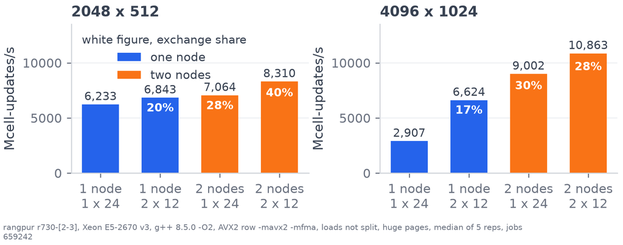

The two node runs on the small grid moved between two jobs minutes apart, 8310 in job 659242 and 9364 in job 659243, so the two node gain there lies between 1.21x and 1.33x. Every other layout agreed within 5 percent.

Two nodes give 1.21x one node on the small grid and 1.64x on the big one. The white figure is the exchange share of a step.

## Tried and rejected

Each bar is one variant against the OpenMP rung, 24 threads

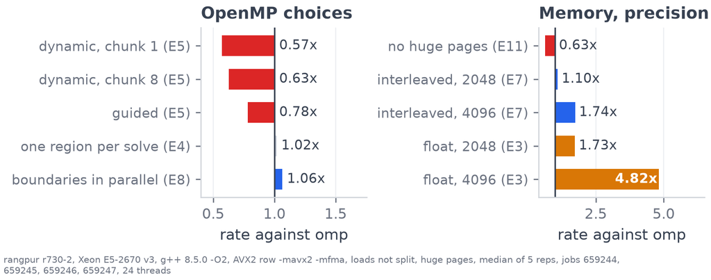

Float gave 1.73x on 2048 by 512 and 4.8x on 4096 by 1024, where its 32 MB fits in the two L3 caches. It priced the option at 196.1256 against 196.1684 in double, and moved gamma by 11.9 percent.

Dynamic scheduling lost, because every row costs the same. Float was faster but moved the price by 4 cents, so it was rejected.

## Same answer on every rung

Price, delta, gamma and vega against the baseline on the test grid

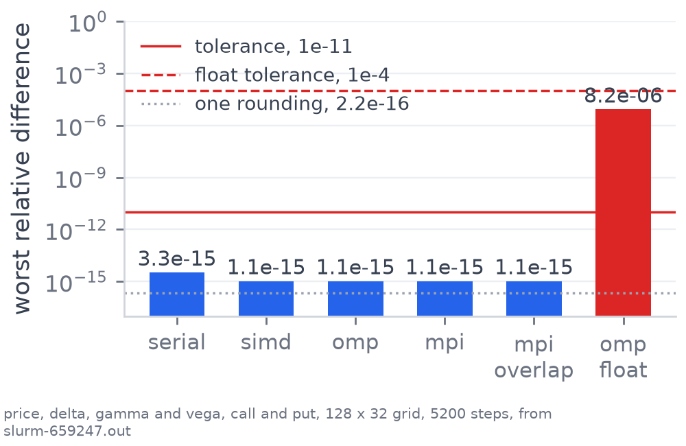

- Every rung is within $3.3 \times 10^{-15}$ of the baseline, a few roundings of a double.
- OpenMP and MPI equal the SIMD rung bit for bit, because they split the same row updates and never sum across workers.
- Float, the red bar, was held to its own limit.
- The tests run on 1, 2 and 7 threads and on 2 and 3 processes, so an uneven split of the 32 test rows is checked too.

No version was timed until it matched, and every benchmark job reran these tests before timing anything.

## Conclusion

The ladder against the measured ceilings

| Rung | Mcell/s | Total |
| --- | --- | --- |
| baseline | 57 | 1x |
| serial | 159 | 2.8x |
| simd | 456 | 8.0x |
| omp, 24 threads | 6367 | 112x |
| mpi, one node | 6984 | 123x |
| mpi, two nodes | 8310 | 147x |

- Serial reached the scalar peak, so the next gain came from SIMD, and unsplit 256 bit loads added 1.19x.
- On 24 threads the 4096 x 1024 grid reached the DRAM bandwidth roof of 68 GB/s, so it is memory bound.
- Across nodes the ghost row exchange is the limit, and overlapping it helps only when Open MPI sends the row eagerly at `MPI_Isend`.

Four of the six hypotheses held. Two nodes were above 80 percent efficient only on 4096 x 1024, and the serial boundary update grew to 9 percent of a step at 24 threads.

## What surprised me, what I would change, and what comes next

Looking back over the project

What surprised me

- With only `-mavx2`, g++ 8.5 split every unaligned 256 bit load into two 128 bit loads. Two flags made simd 1.19x faster.
- Grids whose two buffers start exactly $2^{24}$ bytes apart ran up to 2.7x slower. The hardware cause is still unknown.
- Huge pages, denormal numbers and first-touch page placement each moved the rates as much as some code changes.

What I would do differently

- Flush denormals to zero before the first sweep. A denormal is a double below $2.2 \times 10^{-308}$, too small for the normal format, and this CPU spends tens of extra cycles on every operation that touches one. Short benchmark runs leave values that small far from the strike, so the whole first round of sweeps was rerun.
- Read the compiler’s assembly for every rung from the start. The split loads only showed up after the first simd build ran at 387.
- Give every slurm job its own copy of the tree from day one. A sync and a `make clean` from other jobs killed two jobs in the first round.

How I would extend it

- On the mpi rung every rank allocates the whole 2048 x 512 grid, 16 MiB, and updates only its own rows (`src/solver_mpi.cpp` line 126). The update reads only the row above and below (`src/stencil.cpp` lines 89 and 90), so a rank needs just its own rows plus one copied row from each neighbour. With 4 ranks on two r730 nodes that is 130 rows, about 4 MiB, so the grid can grow with the nodes.
- `OMPI_MCA_btl_vader_eager_limit` above the 16 KiB row, to test why E9 helped only between nodes.
- An implicit or ADI scheme with no limit on $\Delta t$, and a CUDA kernel for the row update.

The build and the system moved the rates as much as the code did, so every result file records the node, the compiler and the flags.

## 123x on one node, 147x on two, the same answer on every rung

Every number has a job id in docs/RESULTS.md

COSC3500 Milestone 2, Zain Al-Saffi

## AI declaration

How AI was used in this project

AI declaration

I used Claude, an AI assistant made by Anthropic, while working on this project. It helped me debug the code, draft pseudocode and implement it, and helped me build the slides, the diagrams and this script.

Every design choice was checked by measurement on rangpur, every number in this video comes from a job listed in `docs/RESULTS.md`, and every source file opens with the same declaration.

## Appendix

Backup slides for questions. They are not part of the video.

## The project in one slide

Price one option by solving a PDE on a grid, then make each step parallel

The question

What is a call option worth today, when the share price and its volatility both move randomly, as in the Heston model?

Why it parallelises

No cell in a step depends on another in the same step, so cells go to AVX2 lanes, rows to cores and blocks of rows to processes.

The method

Solve the Heston PDE on a grid of share price by variance, stepping back from expiry, where every value is known, to today.

The result

123x on one node and 147x on two, with the same answer on every version.

## Checking the answer

With $\xi = 0$ and $\rho = 0$ the variance never moves and Heston becomes Black-Scholes

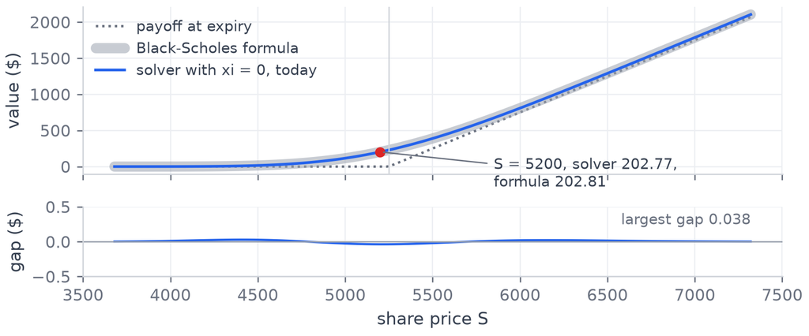

Every benchmark job first runs four tests. `test_bs_collapse` is this check, `test_parity` checks $C - P = S e^{-qT} - K e^{-rT}$ on the full model, `test_ladder_matches` holds every rung to the baseline, and `test_avx_row` holds the AVX2 row to the scalar row.

With its full stencil unchanged, the solver is within 4 cents of the closed form at today’s price. Every benchmark job runs this check first.

## The ladder

Each rung adds one technique and must give the baseline’s answer before it is timed

[figure not shown]

| Rung | Technique |
| --- | --- |
| **baseline** | the original loop, with divisions inside it |
| **serial** | divisions turned into multiplications |
| **simd** | four cells per AVX2 instruction |
| **omp** | the rows shared between 24 cores |
| **mpi** | one process per socket, edge rows exchanged |

The white number inside each bar is the gain over the rung below. The total on one node is 123x the baseline.

## The compiler was splitting the loads

Experiments E2 and E2b, the same source built two ways

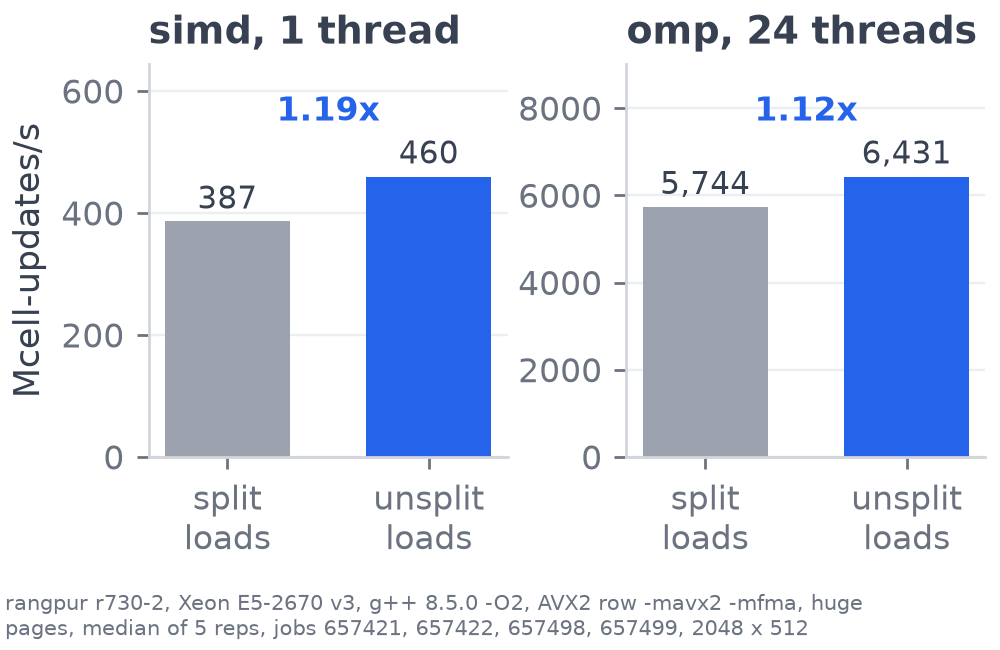

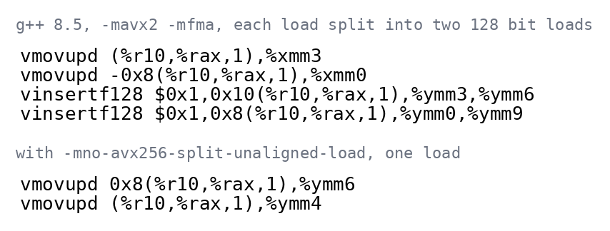

With only `-mavx2`, g++ 8.5 tunes for a generic x86 and compiles every unaligned 256 bit load as two 128 bit loads. With the same flags, the compiler’s own vectorised serial row reaches 77 percent of the hand-written AVX2 row.

```
Makefile, line 23
```

```
NOSPLIT = -mno-avx256-split-unaligned-load -mno-avx256-split-unaligned-store
```

Two flags make every unaligned load one 256 bit load, with the same answer and 1.19x the speed on one core. Every number in this video uses them.

## SIMD on the roofline

Measured ceilings of one r730 core

[figure not shown]

- 31 flops per cell, 15 for the five differences and 16 for the terms and the step, with an FMA counted as two.
- 24 bytes per cell, 8 read, 8 written and 8 more because a store first reads its cache line. So every rung sits at 31 / 24 = 1.29 flops per byte.
- simd is below 4x serial because four cells need nine overlapping loads and two table loads, unaligned loads cross a cache line every other pass, and one core already streams about 11 of its 12.4 GB/s.

simd does 14 GFLOP/s, a third of the AVX2 ceiling and just under the one-core memory roof. On 4096 x 1024 memory slows it by 14 percent.

S. Williams, A. Waterman and D. Patterson, Roofline: an insightful visual performance model for multicore architectures, *Communications of the ACM* 52(4), 65 to 76, 2009.

## MPI code, the time loop

The OpenMP rung’s time loop

```
src/solver_omp.cpp, lines 39 to 59, timer lines left out
```

```cpp
for (int step = 1; step <= num_timesteps; ++step) {
    // Split the interior rows between the threads, one equal band each.
    // Threads only read current and only write their own rows of next, so no locks are needed.
    #pragma omp parallel for schedule(static) default(none) shared(constants, current, next, num_variance_nodes)
    for (int var_j = 1; var_j < num_variance_nodes - 1; ++var_j) {
        update_row_avx(constants, current, next, var_j);
    }

    // The parallel for ends with every thread waiting for the others.
    // Only the main thread runs the boundaries.
    // The top row goes last because it copies the row below.
    update_zero_row(constants, current, next);
    apply_stock_edges(constants, next, 0, num_variance_nodes, step * dt);
    copy_top_row(constants, next);

    // Swap the buffers for the next step.
    grid.swap_buffers();
}
```

Each process updates only its own rows and the boundaries it owns, then exchanges its edge rows before the buffers swap.

## MPI code, the time loop

The same loop with the changes for MPI marked

```
src/solver_mpi.cpp, line 145 and lines 156 to 190, timer lines left out
```

```cpp
RowRange owned_rows = rows_for_rank(num_variance_nodes, rank, num_ranks);
for (int step = 1; step <= num_timesteps; ++step) {
    // Split this process's interior rows between its threads.
    #pragma omp parallel for schedule(static) default(none) shared(constants, current, next, first_interior, end_interior)
    for (int var_j = first_interior; var_j < end_interior; ++var_j) {
        update_row_avx(constants, current, next, var_j);
    }

    // Only the owning process updates each boundary.
    if (owns_zero_row) {
        update_zero_row(constants, current, next);
    }
    apply_stock_edges(constants, next, owned_rows.begin, owned_rows.end, step * dt);
    if (owns_top_row) {
        copy_top_row(constants, next);
    }

    // Send the edge rows to the neighbours and receive theirs.
    // The next step reads one row past each end of this process's rows.
    exchange_edge_rows(next, num_stock_nodes, owned_rows, rank, num_ranks);

    grid.swap_buffers();
}
gather_rows(grid, num_stock_nodes, num_variance_nodes, rank, num_ranks);
```

Each process updates only its own rows and the boundaries it owns, then exchanges its edge rows before the buffers swap.

## Overlapping the exchange with the update

Experiment E9, the edge rows sent first while the other rows are updated

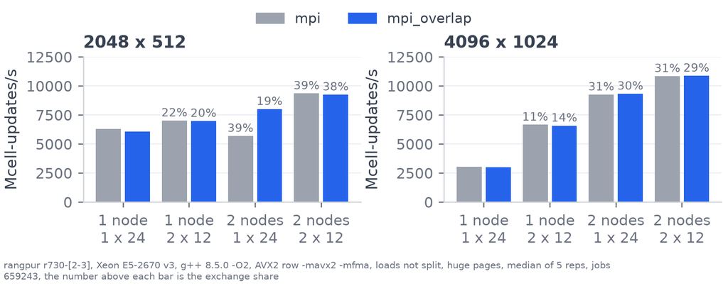

Between nodes Open MPI 4.1.1 uses TCP with a 64 KiB eager limit, so a 16 KiB row leaves at `MPI_Isend`. Within a node shared memory has a 4 KiB eager limit, so the row waits for a rendezvous inside `MPI_Waitall`, and there is no progress thread. Raising that limit above 16 KiB would test this.

It helps only with one process per node, 1.41x. Within a node Open MPI most likely transfers a 16 KiB row only during `MPI_Waitall`.

## The problem

The price today of the right to buy a share at a fixed price on a fixed day

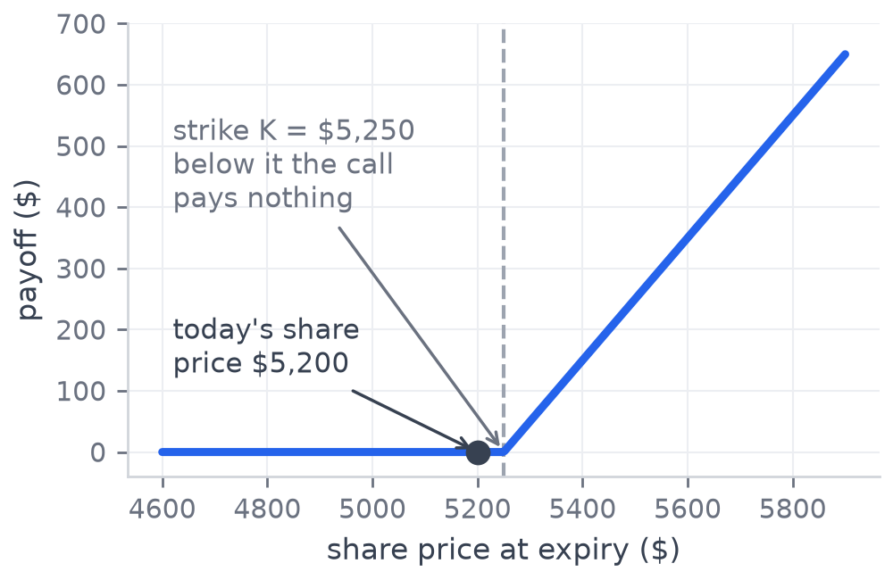

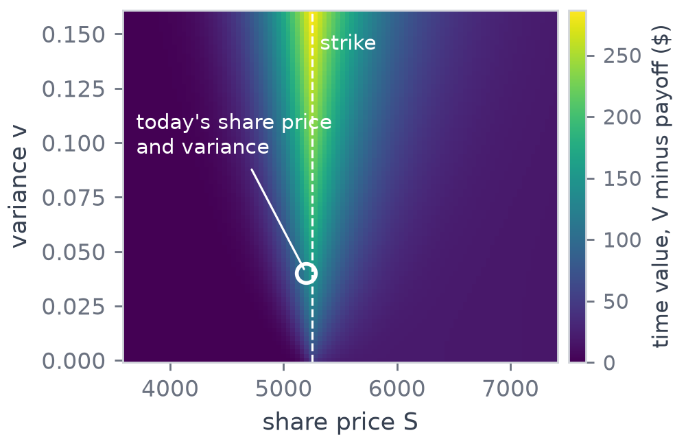

Black-Scholes holds the volatility constant. Heston lets the variance move randomly too, so the value depends on $S$, $v$ and $t$.

## The equation

The value $V(S, v, t)$ solves one PDE, and each term has a plain meaning

$$V_t + \tfrac{1}{2} v S^2 V_{SS} + \rho\xi v S\, V_{Sv} + \tfrac{1}{2}\xi^2 v\, V_{vv}
+ (r - q) S\, V_S + \kappa(\theta - v)\, V_v - r V = 0$$

| Term | Meaning |
| --- | --- |
| $\tfrac{1}{2} v S^2 V_{SS}$ | Diffusion in the share price, from its random movement. |
| $\rho \xi v S V_{Sv}$ | The correlation between the share and its variance. With $\rho = -0.7$ a falling share raises volatility. |
| $\tfrac{1}{2} \xi^2 v V_{vv}$ | Diffusion in the variance, scaled by the volatility of volatility $\xi$. |
| $(r - q) S V_S$ | The share drifts at the risk-free rate less the dividend yield. |
| $\kappa (\theta - v) V_v$ | Mean reversion of the variance towards its long-run level $\theta$ at rate $\kappa$. |
| $- r V$ | Discounting, because money later is worth less than money now. |

On the grid each derivative becomes a difference of neighbouring cells, and one step adds $\Delta t$ times these six terms to the old value.

## What the compiler does alone

The baseline and serial rungs built at -O0 to -O3, the same answer at every level

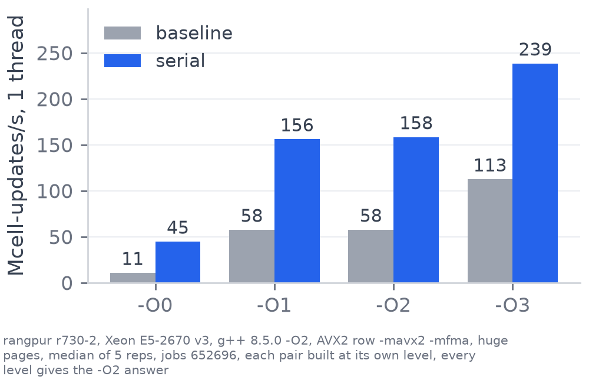

- The baseline goes from 11 at -O0 to 58 at -O2.
- -O3 vectorises with two-lane SSE. That doubles the baseline and gives serial 1.5x.
- Every benchmark builds at -O2, so each rung measures the change written by hand.

At -O3 the compiler takes the baseline to 113, still below the serial rung’s 159 at -O2.

## Could the compiler have written it?

Experiment E1, the whole program rebuilt under stronger flags, one thread

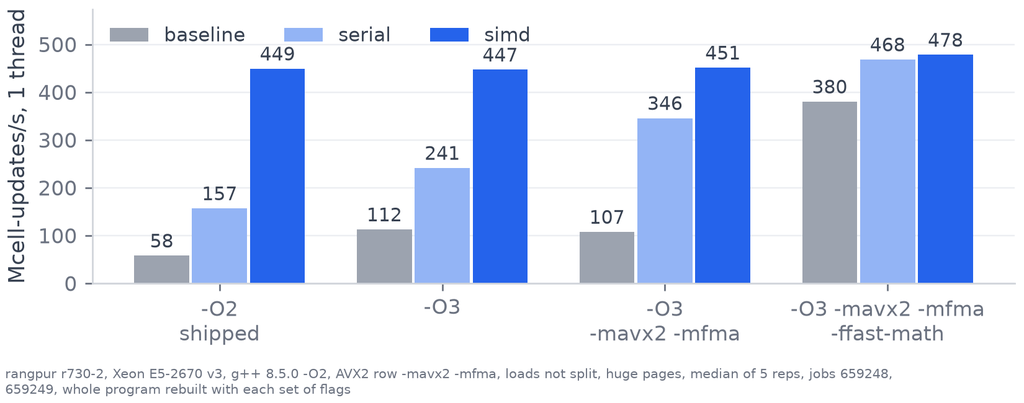

Given AVX2, g++ reaches 0.77x of the hand-written row. -ffast-math rewrites the divisions too, but drops the IEEE rules for the whole program.

## Where each step goes

Parallel rows, serial boundaries and the edge row exchange, 2048 x 512

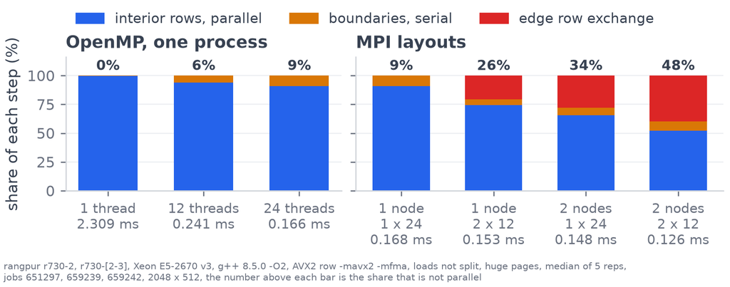

At 24 threads the serial boundaries take 9 percent of a step, as the main thread reads rows other cores just wrote.

## Where everything is

The files to open, in the order the video meets them

| File | What it holds |
| --- | --- |
| `include/grid.h` | The grid, `index()` and the two buffers. |
| `src/solver_baseline.cpp` | Rung 0, the original loop nest with the divisions inside it. Every rung is checked against it. |
| `src/stencil.cpp` | The constants worked out once, the scalar row and the boundaries. |
| `src/stencil_avx.cpp` | The AVX2 row, the only file built with `-mavx2 -mfma`, with a scalar fallback. |
| `src/solver_{serial,simd,omp,mpi}.cpp` | Rungs 1 to 4, one time loop each. |
| `src/solver.cpp` | `make_solver`, the stability report and reading the price off the grid. |
| `src/solver_experiments.cpp` | Experiments E4, E5 and E8. E2 is in `solver_align.cpp`, E3 in `solver_float.cpp`, E9 in `solver_mpi.cpp`. |
| `tests/` | Four test programs, run by `make test` and `make test-mpi`. |
| `slurm/` | One job script per sweep, all sharing `bench_common.sh`. |
| `scripts/` | Every figure, drawn from the CSVs the jobs wrote. |
| `docs/RESULTS.md` | Every number, with its job id. |

## The Heston model

Where the PDE comes from

Two random processes

$$\begin{aligned}
dS &= (r - q) S\,dt + \sqrt{v}\, S\, dW_S \\
dv &= \kappa (\theta - v)\,dt + \xi \sqrt{v}\, dW_v \\
dW_S\, dW_v &= \rho\, dt
\end{aligned}$$

The Feynman-Kac theorem turns the expected discounted payoff into the PDE. The random terms become the second derivatives, so the program has no random number generator.

| Parameter | Value |
| --- | --- |
| today’s share price $S_0$ | 5200 |
| strike $K$, expiry $T$ | 5250, 0.25 y |
| rate $r$, dividend yield $q$ | 0.045, 0.013 |
| $v_0 = \theta$ | 0.04 |
| $\kappa$, $\xi$, $\rho$ | 1.5, 0.35, -0.7 |
| grid | 2048 x 512 |

## The five differences

The nine cells a step reads, and what each difference measures

|  | Difference | What it measures |
| --- | --- | --- |
| $V_S$ | (east $-$ west) $/\, 2\Delta S$ | how steeply value rises with share price |
| $V_{SS}$ | (east $- 2V +$ west) $/\, \Delta S^2$ | how curved it is along the share price |
| $V_v$ | (north $-$ south) $/\, 2\Delta v$ | how value changes with variance |
| $V_{vv}$ | (north $- 2V +$ south) $/\, \Delta v^2$ | how curved it is along the variance |
| $V_{Sv}$ | (ne $-$ nw $-$ se $+$ sw) $/\, 4\Delta S \Delta v$ | how the share slope changes with variance, so it needs the four corners |

The serial rung multiplies by $1/(2\Delta S)$ and the others, worked out once per solve, where the baseline divides in every cell.

## The boundaries

Each edge of the grid has its own rule, all serial in the OpenMP rung

| Edge | Rule |
| --- | --- |
| $v = 0$, the bottom row | Every diffusion term has a factor $v$, so only the drift terms are left. $V_v$ looks one row up, because there is no row below. |
| $S = 0$, the first column | A call is worth nothing there. A put is worth the discounted strike. |
| largest $S$, the last column | A call is worth $S e^{-q\tau} - K e^{-r\tau}$ there, and a put nothing. |
| the top variance row | A copy of the row below, so the value stops changing with variance at the top. It runs last. |

On one thread the boundaries are 0.4 percent of a step. At 24 threads they are 9 percent, because the main thread has to fetch rows that other cores just wrote.

## The timestep limit

An explicit scheme is only stable below a largest timestep

$$\Delta t_{\text{stable}} = \frac{1}{v_{\max} S_{\max}^2 / \Delta S^2 + \xi^2 v_{\max} / \Delta v^2 + r}$$

- The far corner of the grid is the worst cell, where the diffusion is largest.
- At 2048 x 512 the limit is $3.66 \times 10^{-7}$ years, so the real three-month solve takes 980000 steps.
- Every benchmark picks its maturity so that $\Delta t$ is 70 percent of the limit (`maturity_for` in `bench_common.sh`).
- Above the limit the solution grows without bound and the price comes out as `nan`.

## Why an explicit scheme

Each new cell comes straight from known values

- An explicit step computes each new cell from the old buffer, $V^{\text{new}} = V + \Delta t \times$ (the six terms), with no equation to solve.
- So the work is a stencil, regular and local, and it splits cleanly between lanes, threads and processes.
- An implicit scheme solves a linear system across the whole grid every step. That couples the cells and is much harder to parallelise.
- The cost of the explicit choice is the timestep limit, so the solver takes many small steps. Each step is the same regular work, and that suits SIMD, threads and processes.

## Reading the price and the Greeks

`extract_result` in `src/solver.cpp`, after the last step

- Today’s share price and variance fall between grid nodes, so the price is interpolated bilinearly from the four cells around that point.
- The same interpolation one cell to each side gives the values the Greeks need.
- Delta and gamma are central differences in the share price, and vega a central difference in the variance, per unit of variance.
- The solver says on stderr when the quote is off a node, so an interpolated price is never mistaken for a node value.

## Flops and bytes per cell

Where the roofline’s x position comes from

31 flops per cell update

15 for the five differences and 16 to add up the PDE terms and step. A fused multiply-add counts as two.

24 bytes per cell update

8 to read the old value, 8 to write the new one, and 8 more because a store first reads the cache line it writes into.

The arithmetic intensity is $31/24 = 1.29$ flops per byte. The rate in GFLOP/s is the measured cell updates per second times 31. The ceilings come from `slurm/bench_peak.sh` on the same node, a scalar and an AVX2 FMA loop for compute and a triad for memory.

## The AVX2 row next to the scalar row

The same sum, one cell or four

```
src/stencil.cpp, lines 121 to 122, one cell
```

```cpp
double change = stock_diffusion_term + cross_term + variance_diffusion_term + stock_drift_term + variance_drift_term - rate * centre;
out_row[stock_i] = centre + dt * change;
```

```
src/stencil_avx.cpp, lines 99 to 109, four cells
```

```cpp
// fmadd(a, b, c) works out a times b plus c with one rounding.
__m256d change = _mm256_mul_pd(stock_diffusion_factor, d2V_dS2);
change = _mm256_fmadd_pd(cross_factor, d2V_dS_dv, change);
change = _mm256_fmadd_pd(variance_diffusion, d2V_dv2, change);
change = _mm256_fmadd_pd(stock_drift_factor, dV_dS, change);
change = _mm256_fmadd_pd(variance_drift, dV_dv, change);
change = _mm256_fnmadd_pd(rate, centre, change);

// Step back one dt and store the four new values.
__m256d new_value = _mm256_fmadd_pd(dt, change, centre);
_mm256_storeu_pd(out_row + stock_i, new_value);
```

## Why SIMD is below 4x

Four lanes, 2.9x measured

- Each group of four cells needs nine overlapping 4-wide loads, plus two for the $S$ and $S^2$ tables.
- The west, centre and east loads are 8 bytes apart, so at most one of them can start on a 32 byte boundary. Every unaligned load crosses a cache line on every other iteration, and that moves the rate by up to 16 percent (E2b).
- At 456 million updates a second one core moves about 11 GB/s, close to the 12.4 GB/s it can stream from memory.
- The last zero to three cells of every row are computed one at a time, and each row first loads its constants into registers.

No hardware counters were available in the jobs, so the loss cannot be split exactly between these causes.

## Where the rows sit in their cache lines

Experiment E2b, one thread, 2048 x 512, with unsplit loads

| Where column 1 sits | Mcell/s |
| --- | --- |
| centre load on a 32 byte boundary | 477 |
| west or east load on a 32 byte boundary | 439 |
| no load on a 32 byte boundary | 412 |
| aligned load instructions, centre aligned | 477 |
| east and west built by register shuffles | 460 |

An aligned load instruction runs at the same speed as an unaligned one at the same address. The rate depends on whether a load crosses a cache line.

## Experiment E1 in full

The whole program rebuilt under each set of flags, one thread, 2048 x 512, Mcell/s

| Build | baseline | serial | simd |
| --- | --- | --- | --- |
| `-O2`, shipped | 57.6 | 157.0 | 449.6 |
| `-O3` | 112.5 | 241.3 | 446.9 |
| `-O3 -mavx2 -mfma` | 107.4 | 345.6 | 451.1 |
| `-O3 -mavx2 -mfma`, unsplit loads in the whole program | 106.4 | 362.7 | 452.0 |
| `-O3 -march=native` | 105.9 | 266.3 | 455.8 |
| `-O2 -ffast-math` | 58.6 | 175.1 | 476.5 |
| `-O3 -ffast-math` | 189.5 | 271.5 | 472.7 |
| `-O3 -mavx2 -mfma -ffast-math` | 380.1 | 468.2 | 478.0 |
| `-O3 -mavx2 -mfma -ffast-math`, unsplit loads in the whole program | 376.8 | 399.3 | 478.2 |

The simd column always has unsplit loads, from the two flags on its own file. Every build gives the `-O2` answers to within $1.1 \times 10^{-14}$. Why `-march=native` slows serial, and why the fast-math serial rung is slower with unsplit loads, has not been found. Jobs 659248 and 659249.

## Why there are no locks

`schedule(static)`, `default(none)` and the barrier

- Each thread reads only `current` and writes only its own rows of `next`. No cell is written by two threads, and no thread reads `next` during the loop.
- `schedule(static)` splits the rows into equal contiguous blocks once. Every row costs the same, so dynamic scheduling only added overhead (E5, up to 43 percent slower).
- `default(none)` makes every variable used in the loop be listed. The loop counter and the variables inside the body are private to each thread.
- The parallel loop ends with an implied barrier, so every row is done before the boundaries and the swap.

## The swap

Two references bound once, still right after every swap

```
src/grid.cpp, lines 29 to 33
```

```cpp
// Swaps which buffer is read and which is written.
// Only the internal pointers are swapped. No numbers are copied.
void Grid::swap_buffers() {
    std::swap(current_, next_);
}
```

```
src/solver_serial.cpp, lines 32 to 35
```

```cpp
// Read from current and write to next.
// swap_buffers swaps the contents of these two vectors.
const std::vector<double>& current = grid.current();
std::vector<double>& next = grid.next();
```

`std::swap` on two vectors swaps their internal pointers and copies no numbers. The references name the two member vectors, so after the swap `current` holds what was just written.

## Constants copied into local variables

Why the row starts with a block of copies

```
src/stencil.cpp, lines 66 to 76
```

```cpp
// Copy the constants into local variables first.
// Otherwise the compiler may reload them from memory after every write.
double dt = constants.dt;
double rate = constants.rate;
double stock_drift = constants.stock_drift;
double inv_two_ds = constants.inv_two_ds;
double inv_ds_sq = constants.inv_ds_sq;
double inv_two_dv = constants.inv_two_dv;
double inv_dv_sq = constants.inv_dv_sq;
double inv_four_ds_dv = constants.inv_four_ds_dv;
int num_stock_nodes = constants.num_stock_nodes;
```

The row writes through a `double*`, and the compiler cannot prove that pointer never points into the constants. Without the copies it would reload every constant after every store. As locals they stay in registers for the whole row.

## Amdahl and Gustafson

The two laws with the measured numbers

Amdahl, a fixed problem

$S(p) = 1 / \big(f + (1 - f)/p\big)$. Fitted by least squares to the strong scaling speedups, $f = 2.4$ percent, more than five times the 0.44 percent of boundary work on one thread. The rest is the fork and barrier every step and the shared cache bandwidth. The scalar row fits 1.6 percent, because a faster row makes those fixed costs a larger share of each step.

Gustafson, a growing problem

$S(N) = f + (1 - f) N$, with $f$ the serial share of the parallel run. Measured on 24 threads $f = 0.09$, and that predicts 22. The measured scaled speedup is 16.

Karp and Flatt 1990, Gustafson 1988, as on the scaling slides.

## Thread binding on the r730 nodes

Why `close` alternates sockets

- The CPUs are numbered even on socket 0 and odd on socket 1 (job 651500 printed each thread’s CPU).
- `OMP_PLACES=cores OMP_PROC_BIND=close` fills CPUs 0, 1, 2, so every even thread count is split evenly over the two sockets.
- `spread` with fewer than 24 threads stays on socket 0, so E6 used it to measure one socket against two.
- Unbound threads were 1.11x faster on the small grid at 24 threads, and the cause has not been found. On the big grid the reps range from 2699 to 4009 within one job, so the comparison there is noise.

## Page placement, numactl and huge pages

Where the memory of the grid comes from

- Linux places a page in the memory of the socket whose thread first writes it, called the first-touch policy. The grid is filled by the main thread, so every page is on socket 0.
- `numactl --interleave=all` spreads the pages over both sockets, 1.74x on the big grid (E7). Without it the runs fall into two groups, near 2800 and near 4000, so the size of the gain depends on which group they fall in.
- One MPI process per socket allocates and fills its own copy, so its pages are local, 2.28x on the big grid.
- `MALLOC_MMAP_THRESHOLD_=1048576` makes every buffer over 1 MiB come from `mmap`, so each repetition gets fresh 2 MiB huge pages. Without it only the first repetition gets them (E11, 0.63x on 24 threads).

U. Drepper, What every programmer should know about memory, Red Hat, 2007, section 5.

## Which rows a process owns

`rows_for_rank`, and `MPI_Gatherv` at the end

```
src/solver_mpi.cpp, lines 24 to 41
```

```cpp
// Works out which rows a process owns when the rows are shared out evenly.
// The first few processes get one extra row each when they do not divide evenly.
static RowRange rows_for_rank(int num_rows, int rank, int num_ranks) {
    int rows_per_rank = num_rows / num_ranks;
    int extra_rows = num_rows % num_ranks;

    RowRange rows;
    if (rank < extra_rows) {
        // One of the first few processes, with one extra row.
        rows.begin = rank * (rows_per_rank + 1);
        rows.end = rows.begin + rows_per_rank + 1;
    } else {
        // Skip past the processes that took an extra row.
        rows.begin = extra_rows * (rows_per_rank + 1) + (rank - extra_rows) * rows_per_rank;
        rows.end = rows.begin + rows_per_rank;
    }
    return rows;
}
```

When the rows do not divide evenly the first processes take one more row each. At the end `MPI_Gatherv` collects the blocks, with one count and offset per process, outside the timed steps.

## E9 in code

The edge rows first, then the messages, then the other rows

```
src/solver_mpi.cpp, lines 308 to 329
```

```cpp
for (int early = 0; early < num_early_rows; ++early) {
    update_row_avx(constants, current, next, early_rows[early]);
}

// Both rows to send are finished once every thread reaches this line.
#pragma omp barrier

// The master thread starts the messages. The other threads do not wait for it,
// because master, unlike single, has no barrier at its end.
#pragma omp master
{
    double post_start = omp_get_wtime();
    // A sent row needs its stock edges before it leaves.
    if (send_below_row >= 0) {
        apply_stock_edges(constants, next, send_below_row, send_below_row + 1, time_to_expiry);
    }
    if (send_above_row >= 0) {
        apply_stock_edges(constants, next, send_above_row, send_above_row + 1, time_to_expiry);
    }
    post_edge_rows(next, num_stock_nodes, owned_rows, rank, num_ranks, requests);
    result.exchange_seconds += omp_get_wtime() - post_start;
}
```

`barrier` makes every thread finish the rows the neighbours need. `master` lets one thread post the messages, and unlike `single` it has no barrier at its end. The other rows follow on lines 331 to 337.

## Why E9 only helped across nodes

How Open MPI 4.1.1 moves a message, read from `ompi_info` on rangpur

- Between nodes it uses TCP, whose eager limit is 64 KiB, so a 16 KiB row is sent as soon as `MPI_Isend` is called.
- Between processes on one node it uses shared memory, whose eager limit is 4 KiB. A 16 KiB row uses the rendezvous protocol and is only transferred once the receiver is inside an MPI call.
- There is no progress thread, so that call is `MPI_Waitall` at the end of the step, and the transfer does not overlap the update.
- The only layout that gained, one process on each of two nodes, is the only one with no two processes on one node.

This explanation fits every small grid layout but has not been tested. Raising the shared memory eager limit above 16 KiB would test it.

## The two node numbers between jobs

The same build and layouts, run minutes apart, Mcell/s

| Layout | 2048, job 659242 | job 659243 | 4096, job 659242 | job 659243 |
| --- | --- | --- | --- | --- |
| 1 node, 1 x 24 | 6233 | 6288 | 2907 | 3045 |
| 1 node, 2 x 12 | 6843 | 7025 | 6624 | 6664 |
| 2 nodes, 1 x 24 | 7064 | 5693 | 9002 | 9262 |
| 2 nodes, 2 x 12 | 8310 | 9364 | 10863 | 10848 |

The two node layouts on the small grid differ between the jobs by more than the repetitions inside one job do. Every other layout agrees within 5 percent. So the two node gain on the small grid lies between 1.21x and 1.33x.

The headline quotes job 659242, the job the hybrid figure is drawn from. Job 659243 is the E9 job, and these are its `mpi` rows.

## MPI started for threads

`MPI_Init_thread` with `MPI_THREAD_FUNNELED`

```
src/main.cpp, lines 114 to 117
```

```cpp
// FUNNELED promises MPI that only the main thread calls it, even while OpenMP threads run.
// The mpi_overlap solver needs that, because its master thread posts messages inside a parallel region.
int thread_level = 0;
MPI_Init_thread(&argc, &argv, MPI_THREAD_FUNNELED, &thread_level);
```

FUNNELED tells MPI that only the main thread calls it while OpenMP threads run. The `mpi` rung calls MPI only outside parallel regions. The `mpi_overlap` rung calls it from the master thread inside one, so it checks the level and refuses to run below it.

## The test that timed out

One 3-process solve of the test grid under three settings

| Solver | close, on cores | passive wait | not bound |
| --- | --- | --- | --- |
| simd | 1.05 s | 1.04 s | 0.62 s |
| omp | 1.04 s | 1.12 s | 0.59 s |
| mpi | 14.24 s | 1.16 s | 0.58 s |
| mpi_overlap | 14.66 s | 1.17 s | 0.60 s |

The bench scripts pinned threads to cores, and the MPI test inherited that, so every process put its two threads on cores 0 and 1. Waiting OpenMP threads busy-wait, so one process held the cores its neighbour needed to finish and send its row. The test now sets `OMP_PROC_BIND=false`, and validation fell from 14 to 2.5 minutes.

## Denormal numbers

Flushed to zero by a library loaded before `main`

```
slurm/flush_denormals.c, lines 10 to 14
```

```c
/* Runs before main. Bit 15 (0x8000) is FTZ, results too small to be a normal double become 0.
   Bit 6 (0x0040) is DAZ, denormal inputs are read as 0. Threads made later copy this setting */
__attribute__((constructor)) static void flush_denormals(void) {
    _mm_setcsr(_mm_getcsr() | 0x8040);
}
```

`__attribute__((constructor))` runs the function before `main`. It sets flush to zero and denormals are zero in the SSE control register. The bench scripts load it with `LD_PRELOAD`, so `heston` itself is unchanged.

| Rung | as is | flushed |
| --- | --- | --- |
| baseline | 53 | 57 |
| serial | 124 | 159 |
| simd | 320 | 454 |
| omp 24 | 4865 | 6484 |

Job 659436. Every price is identical to ten digits either way.

## The 2<sup>24</sup> byte address effect

A slow point in the grid size sweep, caused by where the two buffers sit in memory

- With split loads, simd on one thread ran at 169 to 183 on any grid whose two buffers sit exactly $2^{24}$ bytes apart, such as 2896 x 724, 1448 x 1448 and 2044 x 1026, and about 405 on the grids next to them. With unsplit loads it still runs at 169 at 2896 x 724.
- omp on 2 threads shows the same, 336 against 814. Serial is slow there too on the current code, 58 at 2896 x 724.
- omp on 24 threads ran at 6499 there in two earlier jobs, and at 3288 and 3267 in the latest two, one with each build, so the flags are not the cause.
- The grids that trigger it are known, and the hardware mechanism has not been found.

The 2896 x 724 points are hollow on the grid size figure for this reason, and its 56x is left out.

## Float buffers

Experiment E3, faster and still rejected

- Float halves the bytes per cell and doubles the lanes per register. On one thread 1.92x simd, on 24 threads 1.73x on 2048 x 512 and 4.8x on 4096 x 1024.
- The big grid gains most, because the float buffers (32 MB) fit in the two L3 caches (60 MB) and the double buffers (64 MB) do not.
- On the reference solve the float price is 196.1256 against 196.1684 in double and 196.1692 from Fourier inversion. The 4 cent error is larger than the discretisation error of a much coarser double grid.
- Gamma moved by 11.9 percent, vega by 2.3 and delta by 0.46.

## The six hypotheses

Written before the sweeps ran, then checked against them

| # | Hypothesis | Outcome |
| --- | --- | --- |
| 1 | SIMD gives 2 to 3.5x over serial | held, 2.9x |
| 2 | OpenMP scales close to linearly to 12 threads | mostly held, 9.6x on 12 threads, 80 percent efficient |
| 3 | the large grid becomes memory-bound | held, on the memory roof at 4096 x 1024 |
| 4 | the serial boundary stays near 0.5 percent | overturned, 9 percent at 24 threads |
| 5 | one process per socket beats one of 24 threads | held, 1.10x and 2.28x |
| 6 | two nodes above 80 percent efficient | overturned at 2048 x 512, 61 percent. Held at 4096 x 1024, 82 percent |

## What the tests check

Run by `make test` and `make test-mpi` before every benchmark

| Test | What it checks |
| --- | --- |
| `test_bs_collapse` | With $\xi = 0$ and $v_0 = \theta$ the variance never moves, and the solver must match Black-Scholes. |
| `test_parity` | Put-call parity, $C - P = S e^{-qT} - K e^{-rT}$, on the full model. It holds in any model, so a gap means a bug. |
| `test_ladder_matches` | Every rung against the baseline within $10^{-11}$, and the parallel rungs against simd to the bit, at 1, 2 and 7 threads and on 2 and 3 processes. |
| `test_avx_row` | The AVX2 row against the scalar row on random grid values. |

7 threads and 3 processes do not divide the 32 test rows evenly, so the uneven split is tested too.

## How the figures were made

Every figure is drawn by a script from files the jobs wrote

| Script | What it draws |
| --- | --- |
| `scripts/m2_figures.py` | Every benchmark chart, from the sweep CSVs, the peak file, a test log and the gprof output. Each bar or point is the median of 5 repetitions in one exclusive job. |
| `scripts/decomposition_diagram.py` | The three diagrams of who owns which cells. |
| `scripts/method_figures.py` | The grid step, the Black-Scholes check and the value map, the last two from `heston --dump-every` snapshots. |
| `scripts/payoff_diagram.py` | The payoff. |
| `scripts/code_shots.py` | The code images of the beamer deck, from the source files. This deck shows the code itself. |

`make m2-figures` redraws every chart. The script refuses any CSV whose host is not a compute node.

## Tests before timing

The job stops unless every test passes

```
slurm/bench_common.sh, lines 60 to 68
```

```bash
# Builds from clean and runs every test.
# Refuses to benchmark anything if a single test fails
build_and_validate() {
  make clean
  make all || { echo "FATAL: build failed, refusing to benchmark"; exit 1; }
  make test || { echo "FATAL: make test failed, refusing to benchmark"; exit 1; }
  make test-mpi || { echo "FATAL: make test-mpi failed, refusing to benchmark"; exit 1; }
  make avx-check || { echo "FATAL: make avx-check failed, refusing to benchmark"; exit 1; }
}
```

Every benchmark job builds from clean, runs `make test`, `make test-mpi` and `make avx-check`, and only then times anything.

## Where a number came from

The header every benchmark CSV carries, written by the job

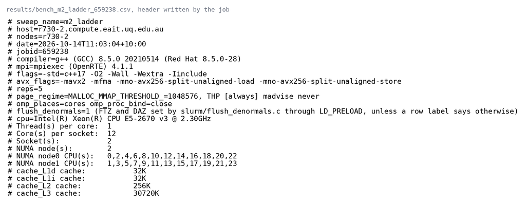